# Introduction to scRNA-seq and data preprocessing

Harvard Chan Bioinformatics Core (HBC) & DFCI Department of Data Science

Author

Affiliations

[Jeremy M. Simon](https://github.com/jeremymsimon/HSPH_scRNA_20241023/)

Dana-Farber Cancer Institute, Department of Data Science

Harvard T.H. Chan School of Public Health, Department Biostatistics

Published

October 23, 2024

Abstract

There are many useful applications of single-cell or single-nucleus RNA-seq technologies to better understand cancer biology. In this introductory workshop, we will discuss some of the advantages of adopting single-cell approaches, frequently utilized technologies/platforms, best practices for experimental design, and provide an overview of algorithms used for data preprocessing. We will then provide an interactive demonstration of single-cell/single-nucleus RNA-seq data preprocessing with `alevin-fry`, resulting in a counts matrix ready for downstream analysis. **This workshop assumes some level of R and unix/linux knowledge**

# Background reading and other resources

A selection of just some of the many great resources out there, this is by no means a comprehensive list

- https://www.sc-best-practices.org/preamble.html
- https://bioconductor.org/books/3.17/OSCA/
- https://r4ds.hadley.nz/
- http://rafalab.dfci.harvard.edu/dsbook/
- https://hbctraining.github.io/scRNA-seq_online/schedule/links-to-lessons.html
- https://combine-lab.github.io/alevin-fry-tutorials/#blog

# Software requirements

These are the minimum requirements, and depending on your system architecture, your needed configuration may vary. I encourage you to discuss with your systems administrator as configuration on a HPC cluster is likely needed anyway for large data

Note we will run these steps individually, which for many samples could be tedious. You may consider the rust wrapper [`simpleaf`](https://github.com/COMBINE-lab/simpleaf) or the nextflow [nf-core single-cell RNAseq pipeline](https://nf-co.re/scrnaseq) instead for larger data

## piscem

- https://github.com/COMBINE-lab/piscem
- https://github.com/COMBINE-lab/piscem/releases/tag/v0.10.3
- `conda install piscem` will work for many users
- Alternatively, there is a parallel path you could follow via `salmon alevin` https://github.com/COMBINE-lab/salmon, which would be run with `--sketch` and `--rad`

## roers

- https://github.com/COMBINE-lab/roers
- First [install Rust](https://doc.rust-lang.org/cargo/getting-started/installation.html)
- You may need to add the installation directory to your `$PATH` environmental variable, e.g. add `export PATH=$PATH:/Users/jsimon/.local/bin` to your `.bashrc` or `.bash_profile`
- Then run `cargo install roers`

## alevin-fry

- https://alevin-fry.readthedocs.io/en/latest/index.html
- https://github.com/COMBINE-lab/alevin-fry
- `conda install alevin-fry`

## others

- Somewhere along the way I needed to run `brew install gfortran openblas pkg-config` followed by `export PKG_CONFIG_PATH="/opt/homebrew/opt/openblas/lib/pkgconfig"` to get scikit-learn to work

## R packages

- `fishpond`
- `SingleCellExperiment`
- `Seurat`
- `Matrix`
- `tidyverse`

```r
BiocManager::install("fishpond")
BiocManager::install("SingleCellExperiment")
install.packages("Seurat")
install.packages("Matrix")
install.packages("tidyverse")
```

# Set up unix/linux workspace

## Make working directory

```bash
mkdir HSPH_scRNA_20241023
cd HSPH_scRNA_20241023
```

## Retrieve example dataset

10X 1k PBMC from a healthy donor, 3’ V3 chemistry, [available here](https://www.10xgenomics.com/datasets/1-k-pbm-cs-from-a-healthy-donor-v-3-chemistry-3-standard-3-0-0)

```bash
# Download 10x FASTQ files
curl -s -O https://cf.10xgenomics.com/samples/cell-exp/3.0.0/pbmc_1k_v3/pbmc_1k_v3_fastqs.tar

# Un-tar FASTQ files
tar -xvf pbmc_1k_v3_fastqs.tar
```

```
x pbmc_1k_v3_fastqs/
x pbmc_1k_v3_fastqs/pbmc_1k_v3_S1_L001_R2_001.fastq.gz
x pbmc_1k_v3_fastqs/pbmc_1k_v3_S1_L002_I1_001.fastq.gz
x pbmc_1k_v3_fastqs/pbmc_1k_v3_S1_L001_R1_001.fastq.gz
x pbmc_1k_v3_fastqs/pbmc_1k_v3_S1_L002_R1_001.fastq.gz
x pbmc_1k_v3_fastqs/pbmc_1k_v3_S1_L002_R2_001.fastq.gz
x pbmc_1k_v3_fastqs/pbmc_1k_v3_S1_L001_I1_001.fastq.gz
```

### Peek at one of the R1 files

```bash
zcat < pbmc_1k_v3_fastqs/pbmc_1k_v3_S1_L001_R1_001.fastq.gz | head -n 24
```

```
@A00228:279:HFWFVDMXX:1:1101:8486:1000 1:N:0:NCATTACT
NGTGATTAGCTGTACTCGTATGTAAGGT
+
#FFFFFFFFFFFFFFFFFFFFFFFFFFF
@A00228:279:HFWFVDMXX:1:1101:10782:1000 1:N:0:NCATTACT
NTCATGAAGTTTGGCTAGTTATGTTCAT
+
#FFFFFFFFFFFFFFFFFFFFFFFFFFF
@A00228:279:HFWFVDMXX:1:1101:12626:1000 1:N:0:NCATTACT
NACCAAAAGGACATCGCGGTAGAGGCTT
+
#FFFFFFFFFFFFFFFFFFFFFFFFFFF
@A00228:279:HFWFVDMXX:1:1101:14452:1000 1:N:0:NCATTACT
NCGTACACAAAGCTCTGTATCTTCATAG
+
#FFFFFFFFFFFFFFFFFFFF:FFFFFF
@A00228:279:HFWFVDMXX:1:1101:24071:1000 1:N:0:NCATTACT
NTCATTTCAAGAGAGAGCACCCGTTATA
+
#FFFFFFFFFFFFFFFFFFFFFFFFF:F
@A00228:279:HFWFVDMXX:1:1101:32461:1000 1:N:0:NCATTACT
NCCTGTTCACAGTCATTATCTACGAGAC
+
#FFFFFFFF:FFFF:,FFFFFFFFFFFF
```

### Peek at one of the R2 files

```bash
zcat < pbmc_1k_v3_fastqs/pbmc_1k_v3_S1_L001_R2_001.fastq.gz | head -n 24
```

```
@A00228:279:HFWFVDMXX:1:1101:8486:1000 2:N:0:NCATTACT
NACAAAGTCCCCCCCATAATACAGGGGGAGCCACTTGGGCAGGAGGCAGGGAGGGGTCCATTCCCCCTGGTGGGGCTGGTGGGGAGCTGTA
+
#FFFFFFFFFFFFFFF:FFFFFFF:FFFFFFFFFFFFFFFFFFFFFFFFFF:FFFFFFFFFFFFFFFF:FFFFFFFFFFFFFFFFFFFFFF
@A00228:279:HFWFVDMXX:1:1101:10782:1000 2:N:0:NCATTACT
NTTGCAGCTGAACTGGTAAACTTGTCCCTAAAGAGACATAAGAATGGTCAACTGGAATGTGGATTCATCTGTAACATTACTCAGTGGGCCT
+
#FFFFFFFFFFFFFFFFFFFFFFFFFFFFFFFFFFFFFFFFFFFFFFFFFFFFFFFFFFFFFFFFFFFFFFFFFFFFFFFFFFFFFFFFFF
@A00228:279:HFWFVDMXX:1:1101:12626:1000 2:N:0:NCATTACT
GCTCCGTAGCCCTGACTGCCTTGGTGACTGTATCCTCAGAAGAATTTGAAGACAAGTGGTTCAGAAAGATCAAAGACCATTTCTGTCCATT
+
FFFFFFFFFFFFFFFFFFFFFFFFFFFFFFFFFFFFFFFFFFFFFFFFFFFFFFFFFFFFFFFFFFFFFFFFFFFFFFFFFFFFFFFFF:F
@A00228:279:HFWFVDMXX:1:1101:14452:1000 2:N:0:NCATTACT
AAAGTTATACTCACAAATTATTATAATGATTACTAATATATTTTTTCCATGTTTCATTGCCTGAATAAAAACTGTTTACCACTGTTAAAAA
+
FFFFFFFFFFFFFFFFFFFFFFFFFFFFFF,FFFFFFFFFFFFFFFFFFFFFFFFFFFFFFFFFFFFF:FFFFFFFFFFFFFFFF:FFFFF
@A00228:279:HFWFVDMXX:1:1101:24071:1000 2:N:0:NCATTACT
CGAGGTCAGGAGTTCAAGACCAGCCTGGCCAACATGGTGAAACACCATTTTTACTAAAAATACAAAAATTAGCTGGGCGTGGTGGTGTGTG
+
FFFFFFFFFFFFFFFFFFFFFFFFFFFFFFFFFFFFFFFFFFFFFFFFFFFFFF:FFFFFFFFFFFFFFFFFFFFFFFFFFF:FFFFFFFF
@A00228:279:HFWFVDMXX:1:1101:32461:1000 2:N:0:NCATTACT
CACAGCTGCTCCTGCTGCTGCTGCAGCCCCAGCTAAGGGTGAAGCCAAGGAAGAGTCGGAGGAGTCGGACGAGGATATGGGATTTGGTCTC
+
FF:FFFFFFFFFFFFFFF:FF:F:FFFFFFFFFF,FFF,FFFFFFF::FF:FFFF:FFFFFFFF:FFF,FFF:FF:::FFF:F,FFFFFF:
```

## Retrieve reference genome and gene annotations

Links are sourced from [GENCODE website](https://www.gencodegenes.org/human/)

```bash
# Download GENCODE GTF of gene annotations
curl -s -O https://ftp.ebi.ac.uk/pub/databases/gencode/Gencode_human/release_45/gencode.v45.annotation.gtf.gz

# Download reference genome sequence
curl -s -O https://ftp.ebi.ac.uk/pub/databases/gencode/Gencode_human/release_45/GRCh38.primary_assembly.genome.fa.gz

# Unzip both files
gunzip GRCh38.primary_assembly.genome.fa.gz
gunzip gencode.v45.annotation.gtf.gz
```

# Prepare reference annotation index

## Generate splici annotation

```bash
# Run roers
roers make-ref -a intronic --filename-prefix splici_roers GRCh38.primary_assembly.genome.fa gencode.v45.annotation.gtf gencode.v45.annotation_splici_roers
```

```
2024-10-21T14:25:56.462925Z  INFO grangers::reader::gtf: Finished parsing the input file. Found 5 comments and 3427477 records.
2024-10-21T14:25:57.139869Z  INFO roers: Built the Grangers object for 3427477 records
2024-10-21T14:25:58.395787Z  INFO roers: Proceed 1650704 exon records from 252930 transcripts
2024-10-21T14:26:33.306413Z  INFO roers: Processing 1397774 intronic records
2024-10-21T14:28:08.686234Z  INFO roers: Done!
```

## Create piscem index of splici annotation

This takes about an hour on my machine, would recommend this be run in a HPC environment

```bash
# Increase number of simultaneous open filehandles
ulimit -n 2048

# Run piscem build
piscem build \
    -s gencode.v45.annotation_splici_roers/splici_roers.fa \
    --output gencode.v45.annotation_splici_roers_piscem_idx \
    -t 4 2> gencode.v45.annotation_splici_roers_piscem_idx.log
```

```
Constructing the compacted reference de Bruijn graph for k = 31.

Enumerating the vertices of the de Bruijn graph.
31-mer enumeration statistics:
    Number of sequences:    331770.
    Total sequence length:  2399553156.
    Total number of 31-mers:    2389600056.
    Number of unique 31-mers:   1584799117.
    Number of solid 31-mers:    1584799117.
Enumerated the vertex set of the graph. Time taken = 35.6151 seconds.
Number of vertices: 1584799117.

Constructing the minimal perfect hash function (MPHF) over the vertex set.
Total number of k-mers in the set (KMC database): 1584799117.
Building the MPHF from the k-mer database ./workdir.noindex/gencode.v45.annotation_splici_roers_piscem_idx_cfish.cf_V.
Using gamma = 7.7.
Built the MPHF in memory.

Total MPHF size: 1863 MB. Bits per k-mer: 9.86382.
Allocated hash table buckets for the k-mers. Total size: 944 MB.
Total memory usage by the hash table: 2808 MB. Bits per k-mer: 14.8638.
Constructed the minimal perfect hash function for the vertices. Time taken = 43.4308 seconds.

Computing the DFA states.

Opened reference 1 from gencode.v45.annotation_splici_roers/splici_roers.fa
Maximum input sequence buffer size used: 4 MB.
Done computing the vertex-states. Time taken = 161.611 seconds.
Computed the states of the automata. Time taken = 161.611 seconds.

Extracting the maximal unitigs.
Temporary path file name prefixes: ./workdir.noindex//cuttlefish-path-output-3562320635

Opened reference 1 from gencode.v45.annotation_splici_roers/splici_roers.fa
["ref_index_builder", "-i", "gencode.v45.annotation_splici_roers_piscem_idx_cfish", "-k", "31", "-m", "19", "--canonical-parsing", "--build-ec-table", "-o", "gencode.v45.annotation_splici_roers_piscem_idx", "-d", "./workdir.noindex", "-t", "4", "--seed", "1"]

Processed 331770 sequences. Total reference length: 2400525620 bases.
Maximum input sequence buffer size used: 4 MB.
Done writing the compacted graph (in GFA-reduced format). Time taken = 658.62 seconds.
Extracted the maximal unitigs. Time taken = 658.622 seconds.
```

[output cut: 9 more lines]

```
buckets with 3 super_kmers = 1.05828%
buckets with 4 super_kmers = 0.332516%
buckets with 5 super_kmers = 0.202043%
buckets with 6 super_kmers = 0.111275%
buckets with 7 super_kmers = 0.0775228%
buckets with 8 super_kmers = 0.0541758%
buckets with 9 super_kmers = 0.0415871%
buckets with 10 super_kmers = 0.0323355%
buckets with 11 super_kmers = 0.0258905%
buckets with 12 super_kmers = 0.0212588%
buckets with 13 super_kmers = 0.0178724%
buckets with 14 super_kmers = 0.0151033%
buckets with 15 super_kmers = 0.0130297%
buckets with 16 super_kmers = 0.011284%
max_num_super_kmers_in_bucket 57949
```

# Count transcripts per cells with `piscem` and `alevin-fry`

## Run `piscem`

As noted in the presentation, the chemistry (V2 vs V3) and orientation (5’ or 3’) impacts these steps and it is easy to configure things incorrectly. Verify all information from your sequencing facility prior to proceeding

More information on `geometry` parameter and possible specifications [here](https://github.com/COMBINE-lab/piscem/blob/main/README.md#geometry)

```bash
piscem map-sc \
  -i gencode.v45.annotation_splici_roers_piscem_idx \
  -1 pbmc_1k_v3_fastqs/pbmc_1k_v3_S1_L001_R1_001.fastq.gz,pbmc_1k_v3_fastqs/pbmc_1k_v3_S1_L002_R1_001.fastq.gz \
  -2 pbmc_1k_v3_fastqs/pbmc_1k_v3_S1_L001_R2_001.fastq.gz,pbmc_1k_v3_fastqs/pbmc_1k_v3_S1_L002_R2_001.fastq.gz \
  --geometry chromium_v3 \
  -o 1k_PBMC_piscem_out \
  -t 4
```

```
2024-10-21T15:00:42.162800Z  INFO piscem: cmd: ["sc_ref_mapper", "-i", "gencode.v45.annotation_splici_roers_piscem_idx", "-g", "chromium_v3", "-1", "pbmc_1k_v3_fastqs/pbmc_1k_v3_S1_L001_R1_001.fastq.gz,pbmc_1k_v3_fastqs/pbmc_1k_v3_S1_L002_R1_001.fastq.gz", "-2", "pbmc_1k_v3_fastqs/pbmc_1k_v3_S1_L001…
[2024-10-21 11:00:42.163] [info] enable structural constraints : false
[2024-10-21 11:00:42.164] [info] No poison k-mer map exists, or it was requested not to be used
[2024-10-21 11:00:42.164] [info] loading index from gencode.v45.annotation_splici_roers_piscem_idx
[2024-10-21 11:00:44.044] [info] done loading index

processed (500000) reads; (435158) had mappings.
processed (1000000) reads; (866928) had mappings.
processed (1500000) reads; (1307333) had mappings.
processed (2000000) reads; (1747336) had mappings.
processed (2500000) reads; (2183151) had mappings.
processed (3000000) reads; (2626305) had mappings.
processed (3500000) reads; (3064362) had mappings.
processed (4000000) reads; (3496324) had mappings.
processed (4500000) reads; (3933725) had mappings.
processed (5000000) reads; (4373168) had mappings.
processed (5500000) reads; (4809272) had mappings.
processed (6000000) reads; (5249175) had mappings.
processed (6500000) reads; (5687871) had mappings.
processed (7000000) reads; (6127604) had mappings.
processed (7500000) reads; (6563113) had mappings.
processed (8000000) reads; (7002116) had mappings.
processed (8500000) reads; (7441732) had mappings.
processed (9000000) reads; (7874514) had mappings.
processed (9500000) reads; (8308827) had mappings.
processed (10000000) reads; (8749777) had mappings.
processed (10500000) reads; (9186610) had mappings.
processed (11000000) reads; (9626227) had mappings.
processed (11500000) reads; (10070560) had mappings.
processed (12000000) reads; (10505161) had mappings.
processed (12500000) reads; (10937583) had mappings.
processed (13000000) reads; (11376439) had mappings.
processed (13500000) reads; (11814702) had mappings.
processed (14000000) reads; (12250578) had mappings.
processed (14500000) reads; (12689635) had mappings.
processed (15000000) reads; (13128992) had mappings.
processed (15500000) reads; (13567895) had mappings.
processed (16000000) reads; (14003409) had mappings.
processed (16500000) reads; (14441073) had mappings.
processed (17000000) reads; (14881968) had mappings.
```

[output cut: 84 more lines]

```
processed (59500000) reads; (52266137) had mappings.
processed (60000000) reads; (52708168) had mappings.
processed (60500000) reads; (53149207) had mappings.
processed (61000000) reads; (53591241) had mappings.
processed (61500000) reads; (54036890) had mappings.
processed (62000000) reads; (54478761) had mappings.
processed (62500000) reads; (54925570) had mappings.
processed (63000000) reads; (55368199) had mappings.
processed (63500000) reads; (55807177) had mappings.
processed (64000000) reads; (56251537) had mappings.
processed (64500000) reads; (56694093) had mappings.
processed (65000000) reads; (57138491) had mappings.
processed (65500000) reads; (57583030) had mappings.
processed (66000000) reads; (58024554) had mappings.
processed (66500000) reads; (58467210) had mappings.[2024-10-21 11:14:08.581] [info] finished mapping.
```

## Run `alevin-fry generate-permit-list`

Note `-d fw` for 10x 3’ v3 chemistry. For v2 chemistry (including 5’), switch to `-d rc`. More information [here](https://github.com/COMBINE-lab/alevin-fry/issues/118)

```bash
alevin-fry generate-permit-list \
  -d fw \
  -k \
  -i 1k_PBMC_piscem_out \
  -o 1k_PBMC_alevin_quant
```

```
2024-10-21 11:14:08 INFO paired : false, ref_count : 331,732, num_chunks : 11,711
2024-10-21 11:14:08 INFO read 2 file-level tags
2024-10-21 11:14:08 INFO read 2 read-level tags
2024-10-21 11:14:08 INFO read 1 alignemnt-level tags
2024-10-21 11:14:08 INFO File-level tag values TagMap { keys: [TagDesc { name: "cblen", typeid: Int(U16) }, TagDesc { name: "ulen", typeid: Int(U16) }], dat: [U16(16), U16(12)] }
2024-10-21 11:14:12 INFO observed 58,558,144 reads in 11,711 chunks --- max ambiguity read occurs in 991 refs
2024-10-21 11:14:12 INFO max_idx = 4518
2024-10-21 11:14:12 INFO max_idx = 1241
2024-10-21 11:14:12 INFO max_idx = 1156
2024-10-21 11:14:12 INFO max_idx = 1151
2024-10-21 11:14:12 INFO knee distance method resulted in the selection of 1152 permitted barcodes.
2024-10-21 11:14:12 INFO total number of distinct corrected barcodes : 69,361
```

## Run `alevin-fry collate`

```bash
alevin-fry collate \
  -r 1k_PBMC_piscem_out \
  -i 1k_PBMC_alevin_quant \
  -t 4
```

```
2024-10-21 11:14:12 INFO filter_type = Filtered
2024-10-21 11:14:12 INFO collated rad file will not be compressed
2024-10-21 11:14:12 INFO paired : false, ref_count : 331,732, num_chunks : 11,711, expected_ori : Forward
2024-10-21 11:14:12 INFO read 2 file-level tags
2024-10-21 11:14:12 INFO read 2 read-level tags
2024-10-21 11:14:12 INFO read 1 alignemnt-level tags
2024-10-21 11:14:12 INFO File-level tag values Ok(TagMap { keys: [TagDesc { name: "cblen", typeid: Int(U16) }, TagDesc { name: "ulen", typeid: Int(U16) }], dat: [U16(16), U16(12)] })
2024-10-21 11:14:12 INFO deserialized correction map of length : 144,068
2024-10-21 11:14:12 INFO Generated 6 temporary buckets.
2024-10-21 11:14:20 INFO writing num output chunks (1,152) to header
2024-10-21 11:14:20 INFO expected number of output chunks 1,152
2024-10-21 11:14:20 INFO finished collating input rad file "1k_PBMC_piscem_out/map.rad".
```

### Peek at our RAD file with `alevin-fry view`

```bash
alevin-fry view -r 1k_PBMC_piscem_out/map.rad | head
```

```
2024-10-21 11:14:21 INFO File-level tag map TagMap { keys: [TagDesc { name: "cblen", typeid: Int(U16) }, TagDesc { name: "ulen", typeid: Int(U16) }], dat: [U16(16), U16(12)] }
ID:0    HI:1    NH:1    CB:CCTTCAGCACAGAGCA UMI:CATACATTTTTT    DIR:true    ENSG00000137478.15-I1
ID:1    HI:1    NH:28   CB:TTTGATCTCTTTGGAG UMI:CCATGGTTGGTT    DIR:true    ENST00000619449.3
ID:1    HI:2    NH:28   CB:TTTGATCTCTTTGGAG UMI:CCATGGTTGGTT    DIR:true    ENST00000710874.1
ID:1    HI:3    NH:28   CB:TTTGATCTCTTTGGAG UMI:CCATGGTTGGTT    DIR:true    ENST00000710861.1
ID:1    HI:4    NH:28   CB:TTTGATCTCTTTGGAG UMI:CCATGGTTGGTT    DIR:true    ENST00000534336.3
ID:1    HI:5    NH:28   CB:TTTGATCTCTTTGGAG UMI:CCATGGTTGGTT    DIR:true    ENST00000710941.1
ID:1    HI:6    NH:28   CB:TTTGATCTCTTTGGAG UMI:CCATGGTTGGTT    DIR:true    ENST00000710875.1
ID:1    HI:7    NH:28   CB:TTTGATCTCTTTGGAG UMI:CCATGGTTGGTT    DIR:true    ENST00000710935.1
ID:1    HI:8    NH:28   CB:TTTGATCTCTTTGGAG UMI:CCATGGTTGGTT    DIR:true    ENST00000710852.1
ID:1    HI:9    NH:28   CB:TTTGATCTCTTTGGAG UMI:CCATGGTTGGTT    DIR:true    ENST00000710855.1
```

## Run `alevin-fry quant`

```bash
alevin-fry quant \
  -m gencode.v45.annotation_splici_roers/t2g_3col.tsv \
  -i 1k_PBMC_alevin_quant \
  -o 1k_PBMC_alevin_quant_crlike \
  -r cr-like \
  -t 4 \
  --use-mtx
```

```
2024-10-21 11:14:21 INFO quantifying from uncompressed, collated RAD file File { fd: 5, path: "/Users/jsimon/Desktop/HSPH_scRNA_20241023/1k_PBMC_alevin_quant/map.collated.rad", read: true, write: false }
2024-10-21 11:14:21 INFO paired : false, ref_count : 331,732, num_chunks : 1,152
2024-10-21 11:14:21 INFO tg-map contained 63,187 genes mapping to 331,732 transcripts.
2024-10-21 11:14:21 INFO read 2 file-level tags
2024-10-21 11:14:21 INFO read 2 read-level tags
2024-10-21 11:14:21 INFO read 1 alignemnt-level tags
2024-10-21 11:14:21 INFO File-level tag values TagMap { keys: [TagDesc { name: "cblen", typeid: Int(U16) }, TagDesc { name: "ulen", typeid: Int(U16) }], dat: [U16(16), U16(12)] }
2024-10-21 11:14:27 INFO processed 50,225,833 total read records
```

### Count how many cells we detected

```bash
wc -l 1k_PBMC_alevin_quant_crlike/alevin/quants_mat_rows.txt
```

```
    1152 1k_PBMC_alevin_quant_crlike/alevin/quants_mat_rows.txt
```

# Import `alevin-fry` counts into R with `fishpond::loadFry()`

```r
library(fishpond)
library(SingleCellExperiment)
library(Seurat)
library(Matrix)
library(tidyverse)

Sample1_RNA <- loadFry("1k_PBMC_alevin_quant_crlike",
    outputFormat = "snRNA")

# Peek at counts
counts(Sample1_RNA)[1:5,1:5]
```

```
5 x 5 sparse Matrix of class "dgCMatrix"
                   GACCCTTCAGCGTATT ATCTCTACAAGAAACT TGAGGTTGTAGCTTTG
ENSG00000237491.10                .                2                1
ENSG00000285268.1                 .                .                .
ENSG00000228794.12                .                .                .
ENSG00000272438.1                 .                .                .
ENSG00000187634.13                .                .                .
                   CTCCATGTCGTCGATA CGTTAGATCATTATCC
ENSG00000237491.10                2                .
ENSG00000285268.1                 .                .
ENSG00000228794.12                .                .
ENSG00000272438.1                 .                .
ENSG00000187634.13                .                .
```

```r
dim(counts(Sample1_RNA))
```

```
[1] 63187  1152
```

# Collapse gene IDs to gene symbols

Note there are some duplicated gene symbols, mainly due to the chrY PAR

```r
tx2gene <- read.table("gencode.v45.annotation_splici_roers/gene_id_to_name.tsv",
                      header = FALSE,
                      sep = "\t",
                      col.names = c("tx","gene"))

# Use matrix multiplication to group and sum counts by gene symbol
exp.txId <- rownames(counts(Sample1_RNA))
exp.geneId <- as.vector(tx2gene$gene[match(exp.txId, tx2gene$tx)])
exp.tx.grp <- t(sparse.model.matrix(~ 0 + exp.geneId))

Sample1_RNA.summarized <- exp.tx.grp %*% counts(Sample1_RNA)
rownames(Sample1_RNA.summarized) <- rownames(Sample1_RNA.summarized) %>% str_replace_all(".+.geneId","")

# Peek at counts again
Sample1_RNA.summarized[1:5,1:5]
```

```
5 x 5 sparse Matrix of class "dgCMatrix"
          GACCCTTCAGCGTATT ATCTCTACAAGAAACT TGAGGTTGTAGCTTTG CTCCATGTCGTCGATA
5_8S_rRNA                .                .                .                .
5S_rRNA                  .                .                .                .
7SK                      .                .                1                .
A1BG                     .                .                .                .
A1BG-AS1                 1                .                .                .
          CGTTAGATCATTATCC
5_8S_rRNA                .
5S_rRNA                  .
7SK                      .
A1BG                     .
A1BG-AS1                 .
```

```r
dim(Sample1_RNA.summarized)
```

```
[1] 61578  1152
```

# Follow basic Seurat workflow

```r
pbmc.seurat <- CreateSeuratObject(Sample1_RNA.summarized)

# Compute mitochondrial contribution per cell and filter out poor quality cells
# Note: My preferred approach here is to use [`MiQC`](https://bioconductor.org/packages/release/bioc/html/miQC.html) rather than set a hard `percent.mt` cutoff
pbmc.seurat <- PercentageFeatureSet(pbmc.seurat,
                                    pattern = "^MT-", # Uses all gene names that begin with "MT-"
                                    col.name = "percent.mt")
pbmc.seurat <- subset(pbmc.seurat, subset = nCount_RNA > 500 & nCount_RNA < 25000 & nFeature_RNA > 250 & percent.mt < 10)
dim(pbmc.seurat)
```

```
[1] 61578   910
```

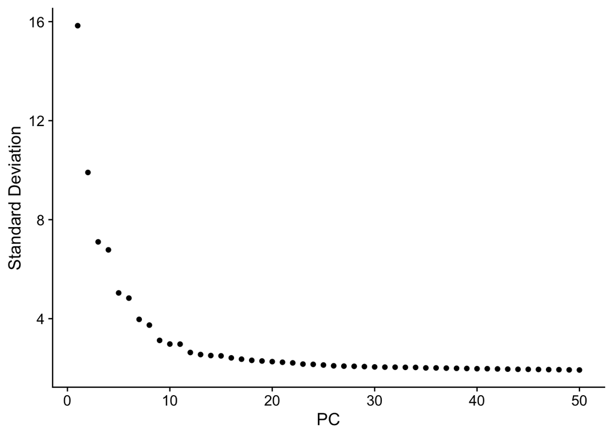

```r
# Normalize and scale data
pbmc.seurat <- NormalizeData(pbmc.seurat)
pbmc.seurat <- FindVariableFeatures(pbmc.seurat,
                                    selection.method = "vst",
                                    nfeatures = 2000)
pbmc.seurat <- ScaleData(pbmc.seurat)

# Run PCA and select "significant" PCs
pbmc.seurat <- RunPCA(pbmc.seurat, npcs = 50)
ElbowPlot(pbmc.seurat, ndims = 50)
```

```r
# Identify clusters
pbmc.seurat <- FindNeighbors(pbmc.seurat, dims = 1:15, reduction = "pca")
pbmc.seurat <- FindClusters(pbmc.seurat, resolution = 0.5, algorithm = 2)
```

```
Modularity Optimizer version 1.3.0 by Ludo Waltman and Nees Jan van Eck

Number of nodes: 910
Number of edges: 25784

Running Louvain algorithm with multilevel refinement...
Maximum modularity in 10 random starts: 0.9017
Number of communities: 10
Elapsed time: 0 seconds
```

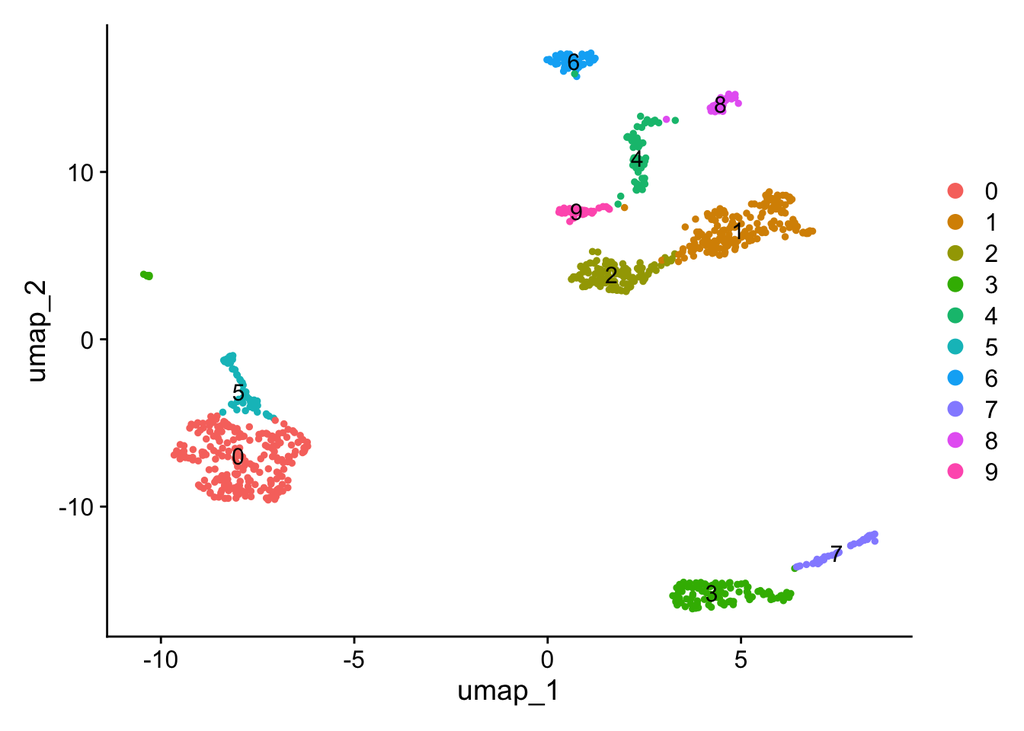

```r
# Visualize with UMAP
pbmc.seurat <- RunUMAP(pbmc.seurat, dims = 1:15)
DimPlot(pbmc.seurat, reduction = "umap", label = TRUE)
```

# Visualize known key features

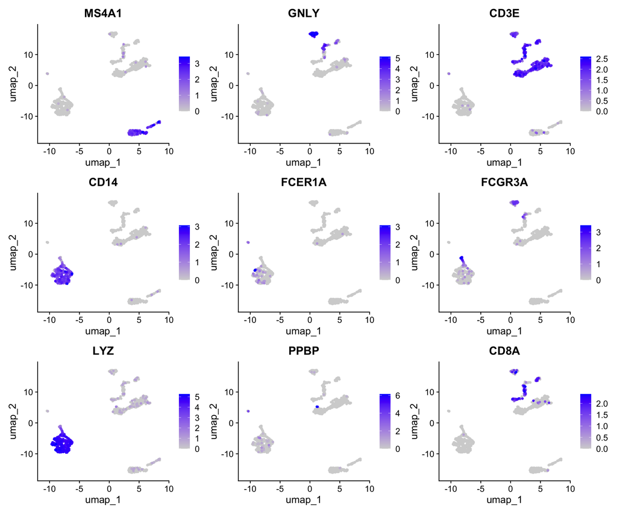

```r
FeaturePlot(pbmc.seurat,
    features = c("MS4A1", "GNLY", "CD3E", "CD14", "FCER1A", "FCGR3A", "LYZ", "PPBP", "CD8A"),
    order = TRUE
    )
```

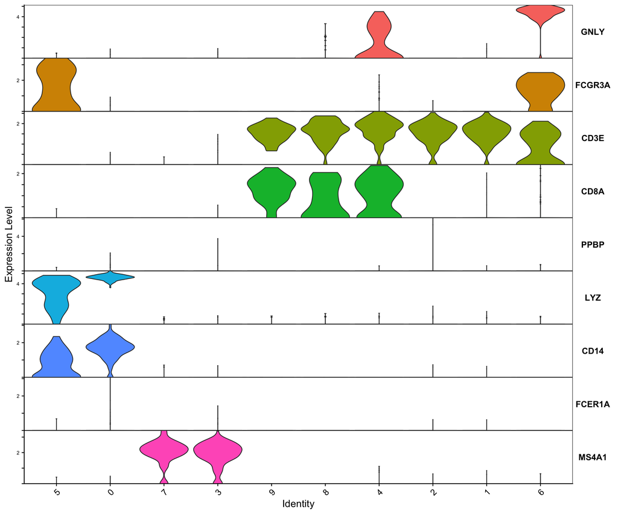

```r
VlnPlot(pbmc.seurat,
    features = c("MS4A1", "GNLY", "CD3E", "CD14", "FCER1A", "FCGR3A", "LYZ", "PPBP", "CD8A"),
    sort = TRUE,
    flip = TRUE,
    stack = TRUE
) + NoLegend()
```